# AMA_Bakery_Data

```python
import numpy as np
import pandas as pd
```

```python
mydataS=pd.read_csv('/content/BakeryData_EDA.csv')
```

```python
mydataS.head()
```

|  | daywk | weekday | Date | Cakes | Pies | Cookies | Smoothies | Coffee | promotion |
| --- | --- | --- | --- | --- | --- | --- | --- | --- | --- |
| 0 | Tuesday | 2 | 01-01-2013 | 79 | 46 | 518 | 60 | 233 | none |
| 1 | Wednesday | 3 | 02-01-2013 | 91 | 50 | 539 | 161 | 427 | none |
| 2 | Thursday | 4 | 03-01-2013 | 47 | 60 | 222 | 166 | 347 | none |
| 3 | Friday | 5 | 04-01-2013 | 89 | 64 | 734 | 153 | 358 | none |
| 4 | Saturday | 6 | 05-01-2013 | 112 | 73 | 764 | 240 | 392 | none |

```python
mydataS.describe()
```

|  | weekday | Cakes | Pies | Cookies | Smoothies | Coffee |
| --- | --- | --- | --- | --- | --- | --- |
| count | 1095.000000 | 1095.000000 | 1095.000000 | 1095.000000 | 1095.000000 | 1095.000000 |
| mean | 3.997260 | 86.280365 | 53.547945 | 540.451142 | 218.466667 | 391.626484 |
| std | 1.999312 | 20.276672 | 13.371886 | 132.354363 | 74.350930 | 102.930517 |
| min | 1.000000 | 32.000000 | 16.000000 | 222.000000 | 50.000000 | 111.000000 |
| 25% | 2.000000 | 73.000000 | 44.000000 | 445.000000 | 165.000000 | 317.500000 |
| 50% | 4.000000 | 85.000000 | 52.000000 | 533.000000 | 206.000000 | 388.000000 |
| 75% | 6.000000 | 98.000000 | 62.000000 | 625.000000 | 261.500000 | 453.000000 |
| max | 7.000000 | 165.000000 | 98.000000 | 1152.000000 | 551.000000 | 771.000000 |

```python
# prompt: Generate code for to calculate skewness for Cakes coloumn in mydata

from scipy.stats import skew

skewness_cakes = skew(mydataS['Cakes'])
print(f"Skewness of Cakes column : {skewness_cakes}")
```

```
Skewness of Cakes column : 0.4265767693990651
```

```python
# prompt: Generate code for to calculate skewness for Cakes, Pies, Cookies , Smoothies and Coffee coloumns in mydata

import numpy as np
import pandas as pd
from scipy.stats import skew
mydataS=pd.read_csv('/content/BakeryData_EDA.csv')
mydataS.head()
mydataS.describe()

# Calculate skewness for each column
columns = ['Cakes', 'Pies', 'Cookies', 'Smoothies', 'Coffee']
for col in columns:
    skewness = skew(mydataS[col])
    print(f"Skewness of {col} column: {skewness}")
```

```
Skewness of Cakes column: 0.4265767693990651
Skewness of Pies column: 0.4734384808410711
Skewness of Cookies column: 0.4396831936948944
Skewness of Smoothies column: 0.7849227902425308
Skewness of Coffee column: 0.36025050150824234
```

```python
# prompt: Generate code for to calculate kurtosis for Cakes, Pies, Cookies , Smoothies and Coffee coloumns in mydata

from scipy.stats import kurtosis

# Calculate kurtosis for each column
columns = ['Cakes', 'Pies', 'Cookies', 'Smoothies', 'Coffee']
for col in columns:
    kurt = kurtosis(mydataS[col])
    print(f"Kurtosis of {col} column: {kurt}")
```

```
Kurtosis of Cakes column: 0.2959505923687189
Kurtosis of Pies column: 0.1172280165350923
Kurtosis of Cookies column: 0.27400648165886077
Kurtosis of Smoothies column: 0.876769273202533
Kurtosis of Coffee column: 0.15534265937002
```

```python
# Generating pivot table (Example: Summing up sales by weekday)
pivot_table = pd.pivot_table(mydataS, values=['Cakes', 'Pies', 'Cookies', 'Smoothies', 'Coffee'],
                             index=['daywk'],
                             aggfunc='sum')

# Display the pivot table
print(pivot_table)
```

```
           Cakes  Coffee  Cookies   Pies  Smoothies
daywk
Friday     14770   66617    93185   9311      36661
Monday     12259   55186    75207   7518      30477
Saturday   16181   73007   102136  10137      41348
Sunday     15054   67784    92648   9277      37484
Thursday   12148   56982    76722   7553      30956
Tuesday    12079   54693    75458   7342      31176
Wednesday  11986   54562    76438   7497      31119
```

```python
import matplotlib.pyplot as plt
import seaborn as sns
```

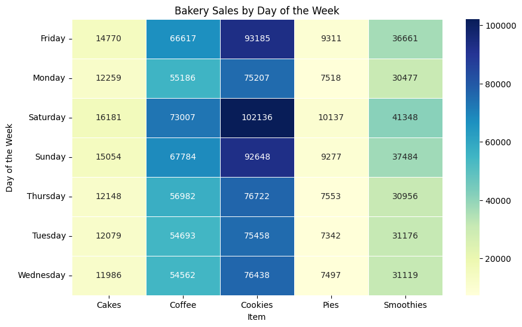

```python
# Create the heatmap
plt.figure(figsize=(10, 6))  # Adjust figure size as needed
sns.heatmap(pivot_table, annot=True, fmt=".0f", cmap="YlGnBu", linewidths=.5) # Customize the colormap and annotation
plt.title('Bakery Sales by Day of the Week')
plt.xlabel('Item')
plt.ylabel('Day of the Week')
plt.show()
```

```python
# Generating pivot table (Example: averaging up sales by weekday)
pivot_table1 = pd.pivot_table(mydataS, values=['Cakes', 'Pies', 'Cookies', 'Smoothies', 'Coffee'],
                             index=['daywk'],
                             aggfunc='mean')

# Display the pivot table
print(pivot_table1)
```

```
                Cakes      Coffee     Cookies       Pies   Smoothies
daywk
Friday      94.679487  427.032051  597.339744  59.685897  235.006410
Monday      78.583333  353.756410  482.096154  48.192308  195.365385
Saturday   103.724359  467.993590  654.717949  64.980769  265.051282
Sunday      96.500000  434.512821  593.897436  59.467949  240.282051
Thursday    77.375796  362.942675  488.675159  48.108280  197.171975
Tuesday     76.936306  348.363057  480.624204  46.764331  198.573248
Wednesday   76.343949  347.528662  486.866242  47.751592  198.210191
```

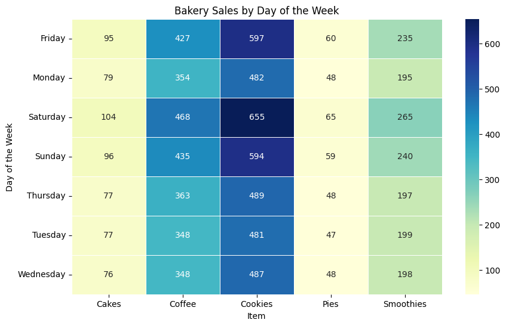

```python
plt.figure(figsize=(10, 6))  # Adjust figure size as needed
sns.heatmap(pivot_table1, annot=True, fmt=".0f", cmap="YlGnBu", linewidths=.5) # Customize the colormap and annotation
plt.title('Bakery Sales by Day of the Week')
plt.xlabel('Item')
plt.ylabel('Day of the Week')
plt.show()
```

```python
# prompt: Generate codes for Creating a new column 'day_type' to categorize days into week day and week end if the day is Sunday and Saturday

# Assuming 'daywk' column represents the day of the week (e.g., 1 for Monday, 7 for Sunday)
mydataS['day_type'] = np.where(mydataS['daywk'].isin(['Monday', 'Tuesday', 'Wednesday', 'Thusday', 'Friday']), 'Weekday', 'Weekend')
```

```python
# Generating pivot table
pivot_table2 = pd.pivot_table(mydataS, values=['Cakes', 'Pies', 'Cookies', 'Smoothies', 'Coffee'],
                             index=['day_type'],
                             aggfunc='mean')

# Display the pivot table
print(pivot_table2)
```

```
              Cakes      Coffee     Cookies       Pies   Smoothies
day_type
Weekday   81.619808  369.102236  511.642173  50.587859  206.761981
Weekend   92.501066  421.690832  578.904051  57.498934  234.089552
```

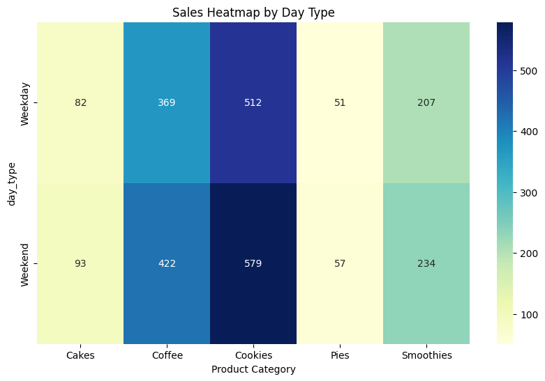

```python
plt.figure(figsize=(10, 6))
sns.heatmap(pivot_table2, annot=True, cmap="YlGnBu", fmt=".0f")
plt.title("Sales Heatmap by Day Type")
plt.xlabel("Product Category")
plt.ylabel("day_type")
plt.show()
```

```python
# prompt: Segregate the data as weekday and weekend and calculate the sum of Cakes, Cookies, Coffee, Pies and Smoothies

import pandas as pd
import numpy as np

# Assuming your data is already loaded into 'mydata' DataFrame
# If not, load it using: mydata = pd.read_csv('/content/BakeryData_EDA.csv')

# Define weekdays and weekends (adjust if your 'daywk' column uses different representations)
weekdays = ['Monday', 'Tuesday', 'Wednesday', 'Thusday', 'Friday']
# Note: Assuming 'Thusday' is a typo and should be 'Thursday'

# Create a 'day_type' column
mydataS['day_type'] = np.where(mydataS['daywk'].isin(weekdays), 'Weekday', 'Weekend')

# Calculate the sum of items for weekdays and weekends
weekday_sales = mydataS[mydataS['day_type'] == 'Weekday'][['Cakes', 'Cookies', 'Coffee', 'Pies', 'Smoothies']].sum()
weekend_sales = mydataS[mydataS['day_type'] == 'Weekend'][['Cakes', 'Cookies', 'Coffee', 'Pies', 'Smoothies']].sum()

# Print the results
print("Weekday Sales:")
print(weekday_sales)
print("\nWeekend Sales:")
weekend_sales
```

```
Weekday Sales:
Cakes         51094
Cookies      320288
Coffee       231058
Pies          31668
Smoothies    129433
dtype: int64

Weekend Sales:
```

|  | 0 |
| --- | --- |
| Cakes | 43383 |
| Cookies | 271506 |
| Coffee | 197773 |
| Pies | 26967 |
| Smoothies | 109788 |

**dtype:** int64

```python
# Generating pivot table
pivot_table3 = pd.pivot_table(mydataS, values=['Cakes', 'Pies', 'Cookies', 'Smoothies', 'Coffee'],
                             index=['day_type'],
                             aggfunc='sum')

# Display the pivot table
print(pivot_table3)
```

```
          Cakes  Coffee  Cookies   Pies  Smoothies
day_type
Weekday   51094  231058   320288  31668     129433
Weekend   43383  197773   271506  26967     109788
```

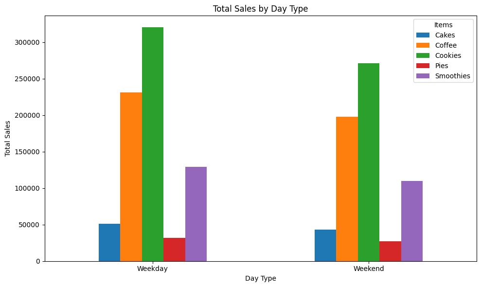

```python
# prompt: convert the pivot_table3 in a bar chart

import matplotlib.pyplot as plt

# Assuming pivot_table3 is already defined as in your previous code

pivot_table3.plot(kind='bar', figsize=(10, 6))
plt.title('Total Sales by Day Type')
plt.xlabel('Day Type')
plt.ylabel('Total Sales')
plt.xticks(rotation=0)  # Rotate x-axis labels if needed
plt.legend(title='Items')
plt.tight_layout()  # Adjust layout to prevent labels from overlapping
plt.show()
```

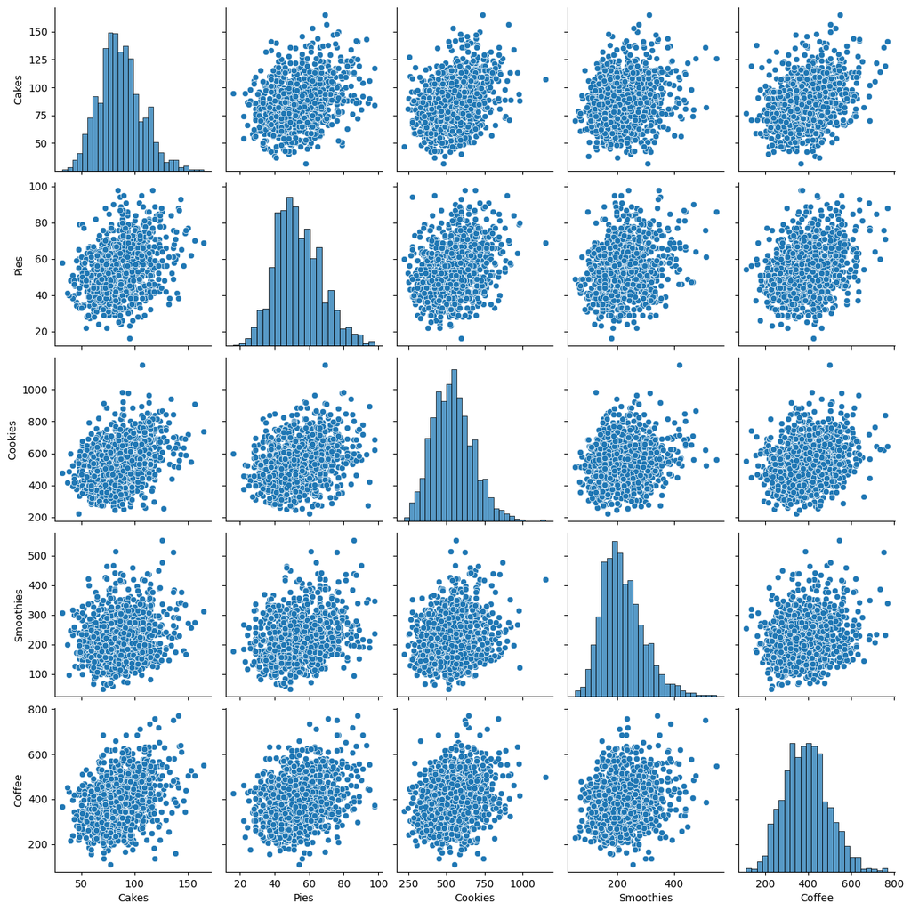

```python
# Remove non-continuous columns for pairplot
continuous_cols = ['Cakes', 'Pies', 'Cookies', 'Smoothies', 'Coffee']
mydata_continuous = mydataS[continuous_cols]

# Create the pairplot
sns.pairplot(mydata_continuous)
plt.show()
```

All the items have week positive correlation, The strong positive correlation should be more than 0.70 and below 0.50 is a week one and the strong positive correlation will have datapoints along with trendline, And dodn't go blindly for the statistical output use common sense

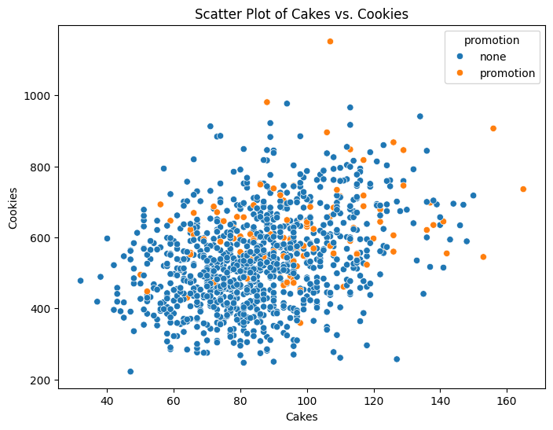

```python
# prompt: Create a scatter plot for Cakes and Cookies hue = promotion

# Assuming 'promotion' column exists in your dataframe. If not, create it or replace with an appropriate column.
plt.figure(figsize=(8, 6))
sns.scatterplot(x='Cakes', y='Cookies', hue='promotion', data=mydataS)
plt.title('Scatter Plot of Cakes vs. Cookies')
plt.xlabel('Cakes')
plt.ylabel('Cookies')
plt.show()
```

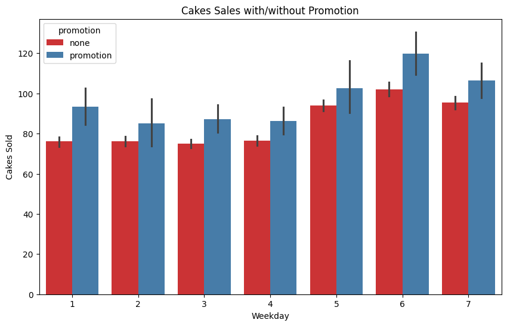

```python
# Barplot for cakes sales based on promotions
plt.figure(figsize=(10,6))
sns.barplot(x='weekday', y='Cakes', hue='promotion', data=mydataS, palette='Set1')
plt.title('Cakes Sales with/without Promotion')
plt.xlabel('Weekday')
plt.ylabel('Cakes Sold')
plt.show()
```

```python
# prompt: generate a pivot table for Cake sale with and without promotion

pivot_table4 = pd.pivot_table(mydataS, values='Cakes', index='weekday', columns='promotion', aggfunc='mean')
pivot_table4
```

| promotion weekday | none | promotion |
| --- | --- | --- |
| 1 | 76.045113 | 93.260870 |
| 2 | 76.139860 | 85.071429 |
| 3 | 75.021429 | 87.235294 |
| 4 | 76.569444 | 86.307692 |
| 5 | 93.965035 | 102.538462 |
| 6 | 102.147887 | 119.714286 |
| 7 | 95.378571 | 106.312500 |

2. How do different product categories (Cakes, Pies, Cookies, Smoothies, Coffee) perform on promotion vs non-promotion days?

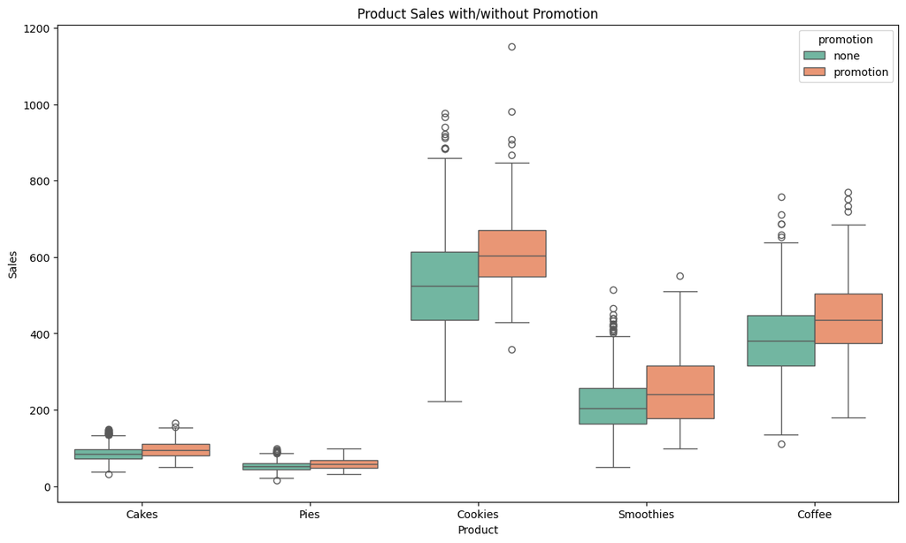

```python
plt.figure(figsize=(14,8))
melted_mydataS = mydataS.melt(id_vars=['weekday', 'promotion'], value_vars=['Cakes', 'Pies', 'Cookies', 'Smoothies', 'Coffee'], var_name='Product', value_name='Sales')
sns.boxplot(x='Product', y='Sales', hue='promotion', data=melted_mydataS, palette='Set2')
plt.title('Product Sales with/without Promotion')
plt.show()
```

```python
# Assuming 'df' is your DataFrame (loaded as in your previous code)
pivot_table = pd.pivot_table(mydataS, values=['Cakes', 'Pies', 'Cookies','Smoothies',	'Coffee'], index='promotion', aggfunc='median')
pivot_table
```

| promotion | Cakes | Coffee | Cookies | Pies | Smoothies |
| --- | --- | --- | --- | --- | --- |
| none | 84.0 | 381.0 | 524.0 | 51.0 | 205.0 |
| promotion | 95.5 | 435.5 | 604.5 | 58.5 | 241.0 |

On which weekday do promotions have the most impact on sales?

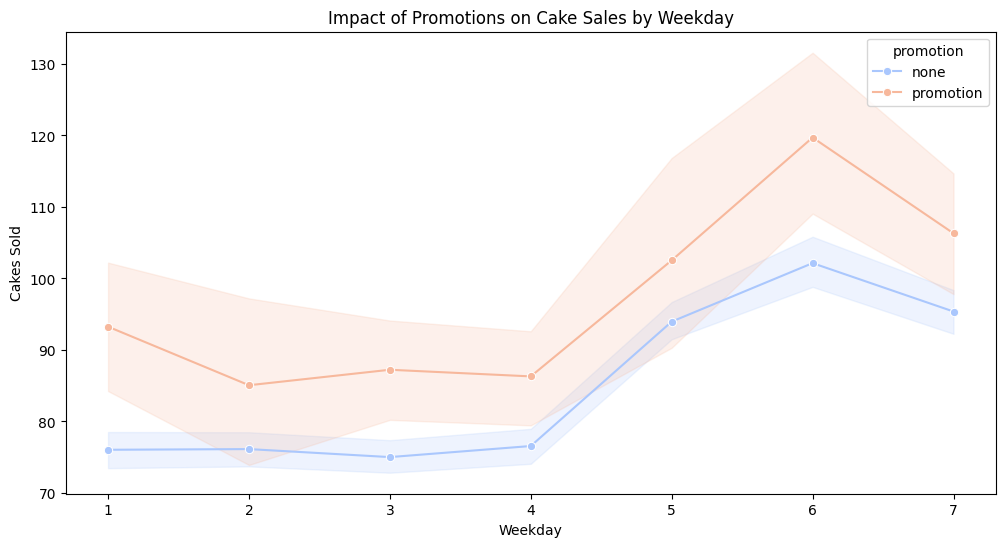

```python
plt.figure(figsize=(12,6))
sns.lineplot(x='weekday', y='Cakes', hue='promotion', data=mydataS, marker='o', palette='coolwarm')
plt.title('Impact of Promotions on Cake Sales by Weekday')
plt.xlabel('Weekday')
plt.ylabel('Cakes Sold')
plt.show()
```

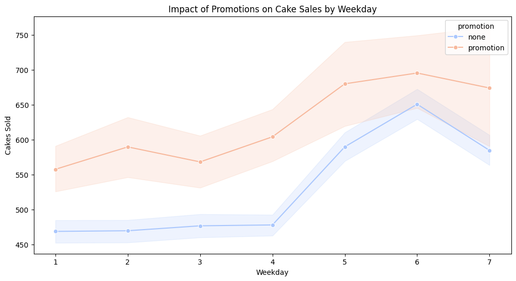

```python
plt.figure(figsize=(12,6))
sns.lineplot(x='weekday', y='Cookies', hue='promotion', data=mydataS, marker='o', palette='coolwarm')
plt.title('Impact of Promotions on Cake Sales by Weekday')
plt.xlabel('Weekday')
plt.ylabel('Cakes Sold')
plt.show()
```

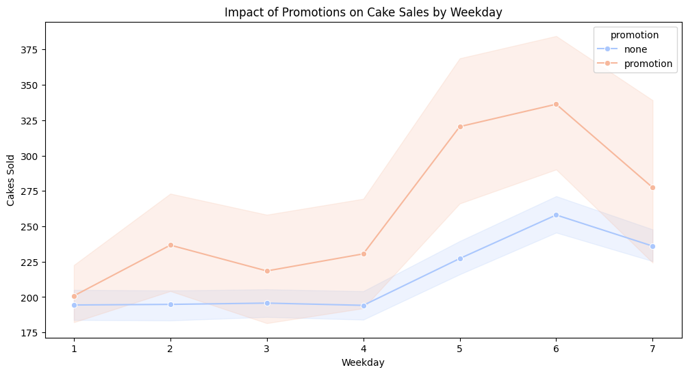

```python
plt.figure(figsize=(12,6))
sns.lineplot(x='weekday', y='Smoothies', hue='promotion', data=mydataS, marker='o', palette='coolwarm')
plt.title('Impact of Promotions on Cake Sales by Weekday')
plt.xlabel('Weekday')
plt.ylabel('Cakes Sold')
plt.show()
```

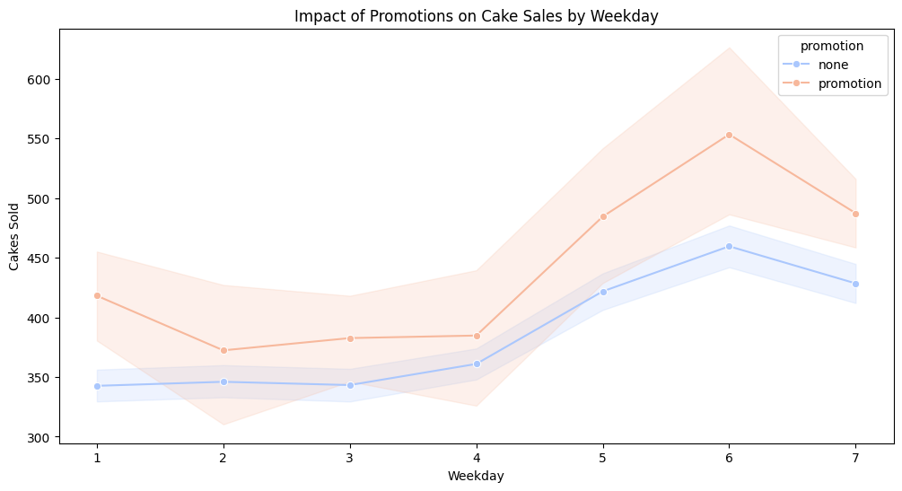

```python
plt.figure(figsize=(12,6))
sns.lineplot(x='weekday', y='Coffee', hue='promotion', data=mydataS, marker='o', palette='coolwarm')
plt.title('Impact of Promotions on Cake Sales by Weekday')
plt.xlabel('Weekday')
plt.ylabel('Cakes Sold')
plt.show()
```

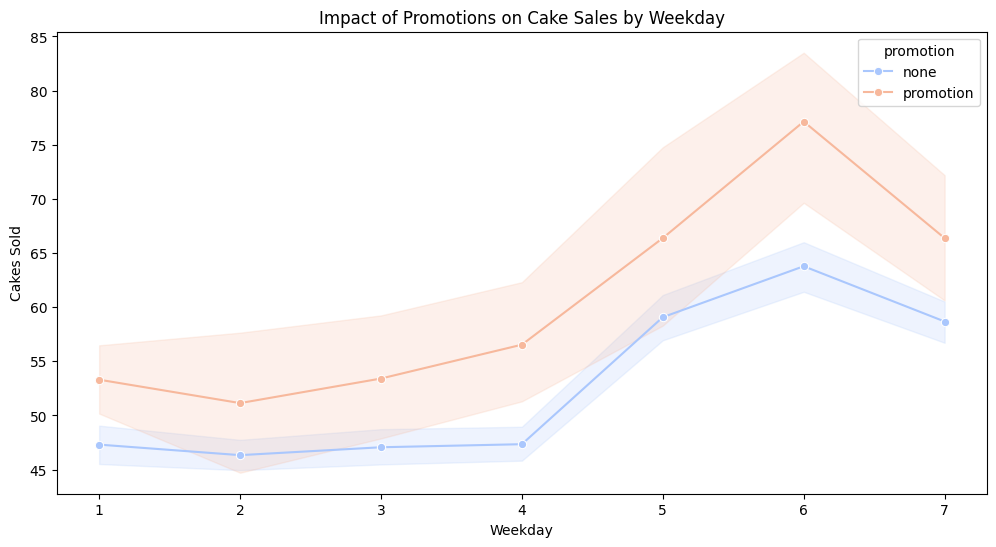

```python
plt.figure(figsize=(12,6))
sns.lineplot(x='weekday', y='Pies', hue='promotion', data=mydataS, marker='o', palette='coolwarm')
plt.title('Impact of Promotions on Cake Sales by Weekday')
plt.xlabel('Weekday')
plt.ylabel('Cakes Sold')
plt.show()
```

```python
# **1. What is the impact of promotions on the sales of cakes?**
pivot_table_cakes = pd.pivot_table(mydataS, values='Cakes', index='weekday', columns='promotion', aggfunc='mean')
print("Impact of promotions on cakes sales:")
print(pivot_table_cakes)

# **2. What is the impact of promotions on the sales of cookies?**
pivot_table_cakes = pd.pivot_table(mydataS, values='Cookies', index='weekday', columns='promotion', aggfunc='mean')
print("Impact of promotions on cookies sales:")
print(pivot_table_cakes)

# **3. What is the impact of promotions on the sales of smoothies?**
pivot_table_cakes = pd.pivot_table(mydataS, values='Smoothies', index='weekday', columns='promotion', aggfunc='mean')
print("Impact of promotions on smoothies sales:")
print(pivot_table_cakes)

# **4. What is the impact of promotions on the sales of coffee?**
pivot_table_cakes = pd.pivot_table(mydataS, values='Coffee', index='weekday', columns='promotion', aggfunc='mean')
print("Impact of promotions on coffee sales:")
print(pivot_table_cakes)

# **5. What is the impact of promotions on the sales of pies?**
pivot_table_cakes = pd.pivot_table(mydataS, values='Pies', index='weekday', columns='promotion', aggfunc='mean')
print("Impact of promotions on Pies sales:")
print(pivot_table_cakes)
```

```
Impact of promotions on cakes sales:
promotion        none   promotion
weekday
1           76.045113   93.260870
2           76.139860   85.071429
3           75.021429   87.235294
4           76.569444   86.307692
5           93.965035  102.538462
6          102.147887  119.714286
7           95.378571  106.312500
Impact of promotions on cookies sales:
promotion        none   promotion
weekday
1          469.015038  557.739130
2          469.944056  589.714286
```

[output cut: 35 more lines]

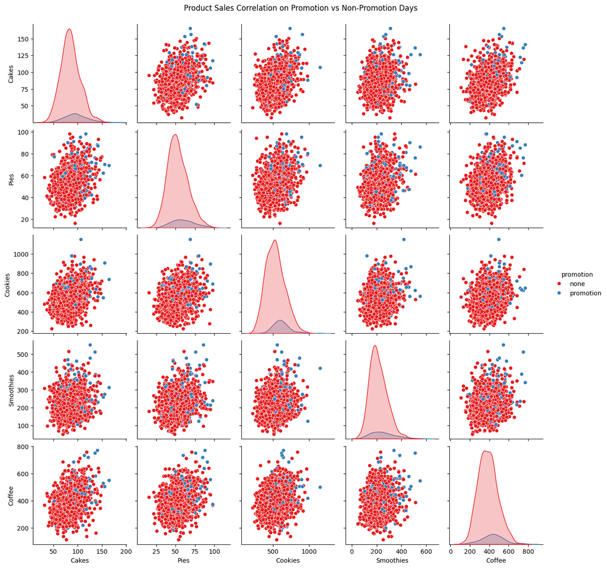

```python
sns.pairplot(mydataS[['Cakes', 'Pies', 'Cookies', 'Smoothies', 'Coffee', 'promotion']], hue='promotion', palette='Set1')
plt.suptitle('Product Sales Correlation on Promotion vs Non-Promotion Days', y=1.02)
plt.show()
```

Do smoothies and coffee sales increase together on promotion days?

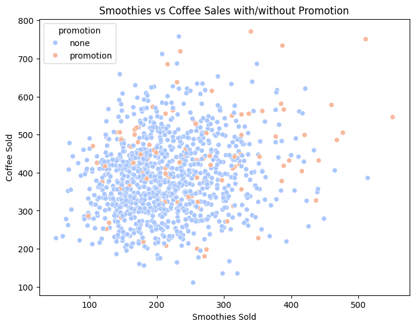

```python
plt.figure(figsize=(8,6))
sns.scatterplot(x='Smoothies', y='Coffee', hue='promotion', data=mydataS, palette='coolwarm')
plt.title('Smoothies vs Coffee Sales with/without Promotion')
plt.xlabel('Smoothies Sold')
plt.ylabel('Coffee Sold')
plt.show()
```